# Table of Contents (Jupyter)

### Visual examination of Exogeneous Variable impact on Time Series

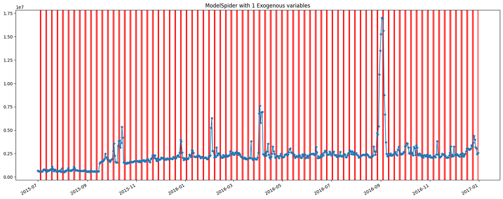

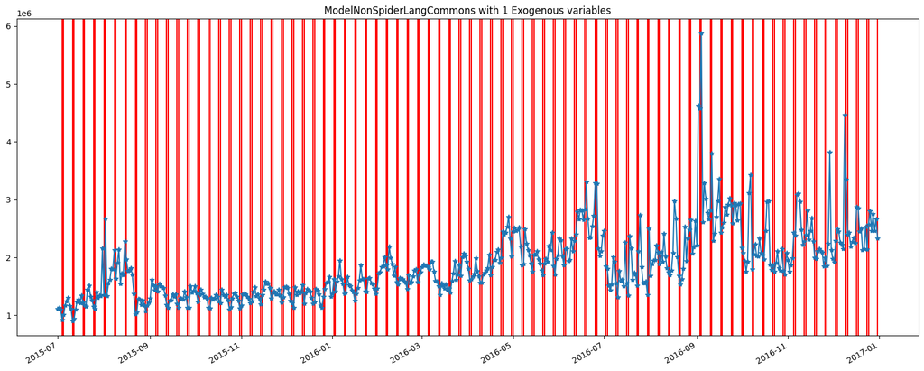

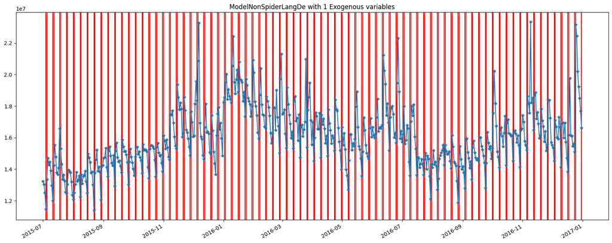

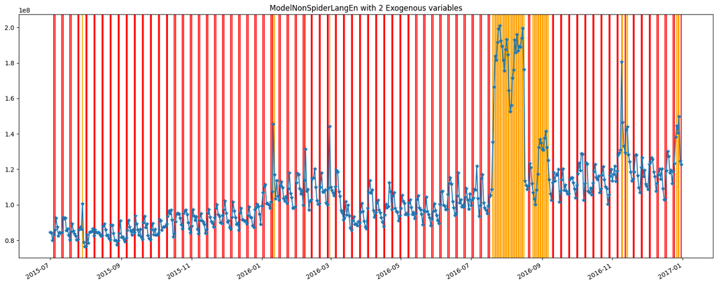

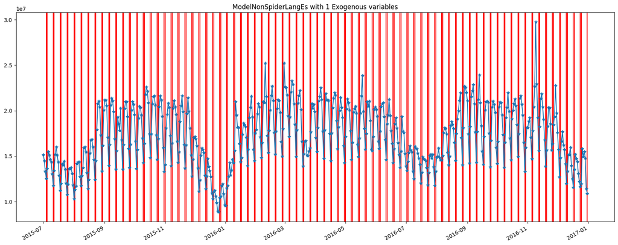

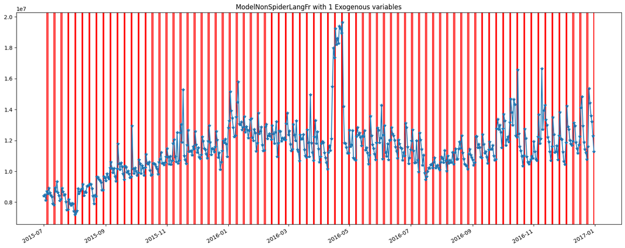

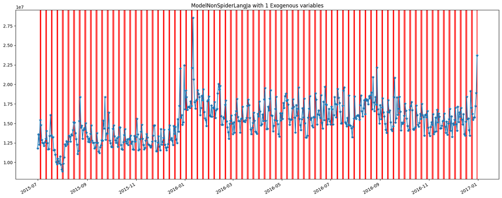

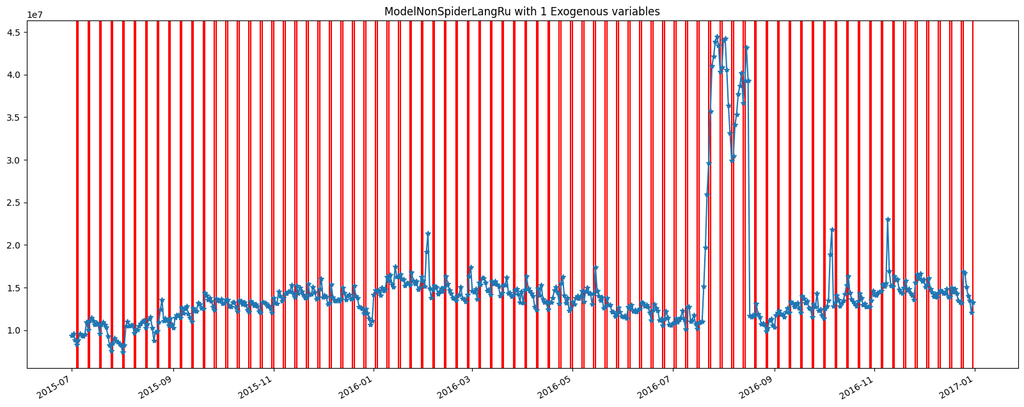

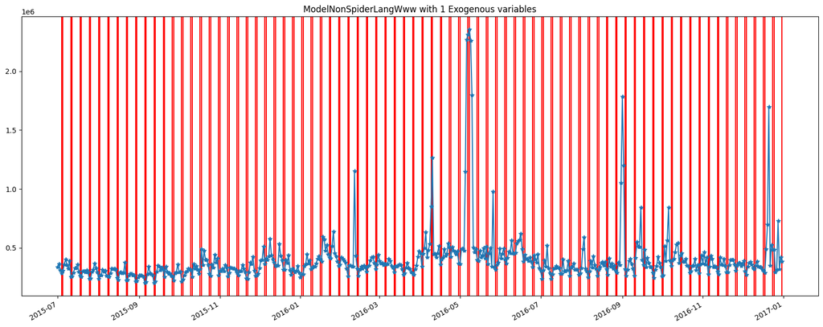

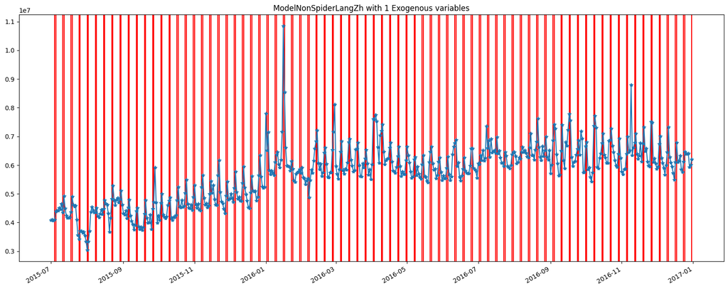

```python
# First we collect all indexes where campaign are there

# def plot_data_with_campaign(data,exogData, segment_names, space):
#     colors = ['red', 'orange', 'purple']
#     for segment in segment_names:
#         for exog in range(space[segment]['numExog']):
#             campaign = exogData[exogData[f'{segment}_exog_{exog}']==1].index
#             for day in campaign:
#                 plt.axvline(x=day, color=colors[exog % len(colors)])
#         data[segment].plot(style='-*')
#         plt.title(f"{segment} with {space[segment]['numExog']} Exogeneous variable")
#         plt.show()

def plot_data_with_campaign(data, exogData, segment_names):
    colors = ['red', 'orange', 'purple']

    for segment in segment_names:
        # find all exogenous columns for this segment
        exog_cols = [col for col in exogData.columns if col.startswith(f"{segment}_exog")]

        for i, col in enumerate(exog_cols):
            campaign_days = exogData[exogData[col] == 1].index
            for day in campaign_days:
                plt.axvline(x=day, color=colors[i % len(colors)])

        data[segment].plot(style='-*')
        plt.title(f"{segment} with {len(exog_cols)} Exogenous variables")
        plt.show()

plot_data_with_campaign(timeSeriesFull_df, exog_df, modelNames)
```

- We have got VERY good results visully...The peaks seem to match the weekend weeday exogeneous shock very nicely across the data.
- Data is suggesting that while the given exogeeous data was for only English, it may be useful for russian too.
- Spider data is not having any effect. We will remove the column for spider.

```python
exog_df = addExogeneousColumnToADataFrame(exog_df, exog_campaign_series,'ModelNonSpiderLangRu_exog_campaign')
exog_df.drop(columns=['ModelSpider_exog_weekend'], inplace=True)
```

```
addExogeneousColumnToADataFrame():Adding the exogeneous variable (campaign data) as a column
```

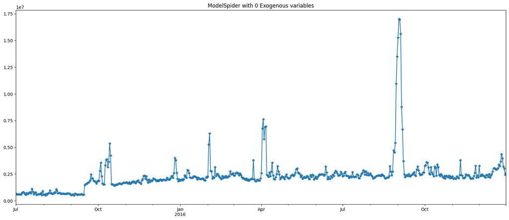

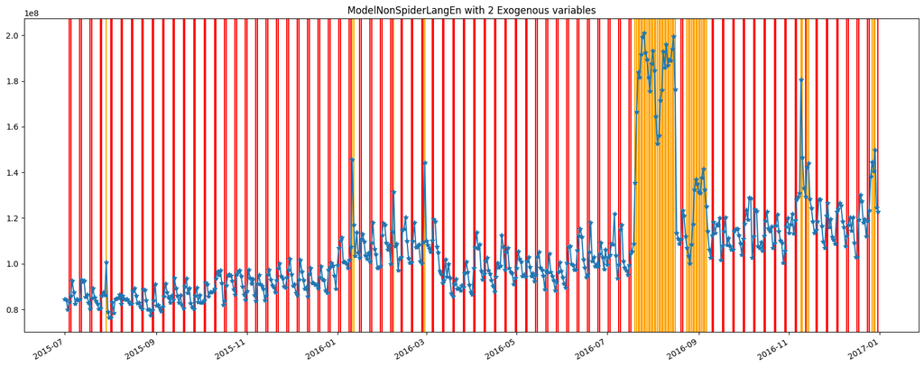

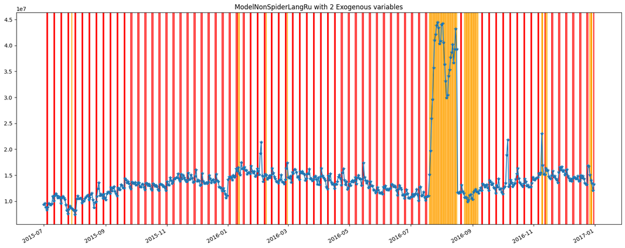

```python
plot_data_with_campaign(timeSeriesFull_df[['ModelSpider','ModelNonSpiderLangEn','ModelNonSpiderLangRu']], exog_df, segment_names=['ModelSpider','ModelNonSpiderLangEn','ModelNonSpiderLangRu'])
```

Russian matched well with English exogeneous regressor.

Exogeneous removed from Spider

```
MAE : 7362033.451
RMSE : 9480060.725
MAPE: 0.06
```

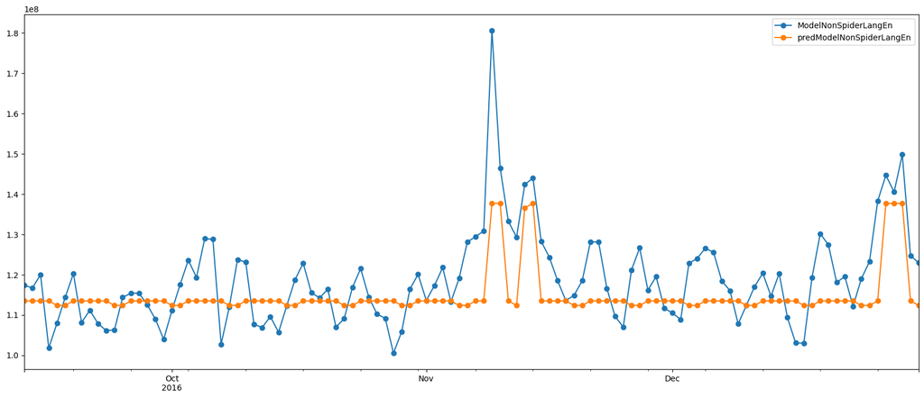

```python
train_x = timeSeriesFull_df.loc[timeSeriesFull_df.index < train_max_date].copy()
test_x = timeSeriesFull_df.loc[timeSeriesFull_df.index >=train_max_date].copy()
exog_train = exog_df.loc[exog_df.index < train_max_date].copy()
exog_test =exog_df.loc[exog_df.index >= train_max_date].copy()
segmentName = modelNames[3]

exog_segment_cols = [col for col in exog_df.columns if col.startswith(f"{segmentName}_exog")]



model = SARIMAX(endog=train_x[segmentName],
                        order=(0, 1, 0),
                        seasonal_order=(0, 0, 0, 7),
                        exog=exog_train[exog_segment_cols],
                        enforce_stationarity=False,
                        enforce_invertibility=False)
fitted = model.fit(disp=False, maxiter=200)

# Forecast
predColumnName = 'pred'+segmentName
test_x[predColumnName] = fitted.forecast(steps=len(test_x[segmentName]), exog=exog_test[exog_segment_cols])
test_x[[segmentName,predColumnName]].plot(style='-o')
# Calculate metrics
mape_val,rmse_val, mae_val = performance(test_x[segmentName], test_x[predColumnName], verbose=True)
```

### Running gridSearchSARIMAXAllSegments

```python
r,b=gridSearchSARIMAXAllSegments(timeSeriesCombined_df = timeSeriesFull_df,
                                modelNames=modelNames,
                                modelDict=modelDict,
                                searchSpace=SARIMAX_SEARCH_SPACE,
                                exog_all_segments_df=exog_df,
                                train_ratio=0.8,
                                metric='mape',
                                searchTitle="SARIMAX GridSearch",
                                comments="Used SARIMAX_SEARCH_SPACE",
                                verbose=False)
```

```
============================================================
GRID SEARCH: ModelSpider
============================================================
Testing 128 combinations...
MAPE: 0.115
  ⏱️ Time: 24.2 seconds

============================================================
GRID SEARCH: ModelNonSpiderLangCommons
============================================================
Testing 128 combinations...
MAPE: 0.141
  ⏱️ Time: 29.0 seconds

============================================================
GRID SEARCH: ModelNonSpiderLangDe
============================================================
Testing 128 combinations...
MAPE: 0.055
  ⏱️ Time: 22.7 seconds

============================================================
GRID SEARCH: ModelNonSpiderLangEn
============================================================
Testing 128 combinations...
MAPE: 0.056
  ⏱️ Time: 31.7 seconds

============================================================
GRID SEARCH: ModelNonSpiderLangEs
============================================================
Testing 128 combinations...
MAPE: 0.089
  ⏱️ Time: 22.0 seconds

============================================================
GRID SEARCH: ModelNonSpiderLangFr
============================================================
Testing 128 combinations...
MAPE: 0.071
```

[output cut: 14 more lines]

```
  ⏱️ Time: 26.8 seconds

============================================================
GRID SEARCH: ModelNonSpiderLangWww
============================================================
Testing 128 combinations...
MAPE: 0.25
  ⏱️ Time: 26.7 seconds

============================================================
GRID SEARCH: ModelNonSpiderLangZh
============================================================
Testing 128 combinations...
MAPE: 0.047
  ⏱️ Time: 22.6 seconds
```

```python
printModelDictSummaryDETAILED(modelDict)
```

**Model Dictionary Summary**

| Model Name | Data Rows | # Attempts | Best Model | Best Params | Best MAPE |
| --- | --- | --- | --- | --- | --- |

[output not shown]

**Validation**

| Metric | Count |
| --- | --- |
| Total rows across models | 145063 |
| Original dataframe rows | 145063 |
| Difference | 0 |

✅ **MATCH:** Total rows equals original dataframe!

**Best MAPE Ranking**

[output not shown]

## Fitting Prophet --------------------------------------

### Prophet helper functions

#### `fitProphetWithRegressors()`

```python
from prophet import Prophet

def fitProphetWithRegressors(prophet_df, exog_cols,
                              train_ratio=0.8,
                              seasonality_mode='multiplicative',
                              changepoint_prior_scale=0.1,
                              seasonality_prior_scale=0.1,
                              weekly_seasonality=True,
                              yearly_seasonality=False,
                              verbose=True):
    """
    Fit Prophet model with exogenous regressors.

    Parameters:
    -----------
    prophet_df : DataFrame with ds, y and any exogeneous columns.
    exog_cols : str or list - exogenous variable column(s)
    train_ratio : float
    seasonality_mode : 'additive' or 'multiplicative'
    changepoint_prior_scale : float
    seasonality_prior_scale : float
    weekly_seasonality : bool
    yearly_seasonality : bool
    verbose : bool

    Returns:
    --------
    results : dict with model, forecast, metrics
    """
    # Remove NaN
    prophet_df = prophet_df.dropna()

    # Train/test split
    n = len(prophet_df)
    train_size = int(n * train_ratio)

    train_df = prophet_df.iloc[:train_size].copy()
    test_df = prophet_df.iloc[train_size:].copy()

    if verbose:
        print(f"Regressors: {exog_cols}")
        print(f"Train size: {len(train_df)}, Test size: {len(test_df)}")
        print(f"Params: seasonality_mode={seasonality_mode}, "
              f"changepoint_prior={changepoint_prior_scale}, "
              f"seasonality_prior={seasonality_prior_scale}")

    try:
        with warnings.catch_warnings():
            warnings.simplefilter("ignore")

            # Initialize Prophet
            model = Prophet(
                seasonality_mode=seasonality_mode,
                changepoint_prior_scale=changepoint_prior_scale,
                seasonality_prior_scale=seasonality_prior_scale,
                weekly_seasonality=weekly_seasonality,
                yearly_seasonality=yearly_seasonality
            )

            # Add regressors
            for col in exog_cols:
                model.add_regressor(col)

            # Fit
            model.fit(train_df)

            # Create future dataframe with regressors
            future = model.make_future_dataframe(periods=len(test_df), freq='D')

            # Add regressor values to future
            full_regressors = prophet_df[exog_cols].values
            for i, col in enumerate(exog_cols):
                future[col] = np.concatenate([
                    full_regressors[:, i],
                    np.zeros(max(0, len(future) - len(full_regressors)))  # Pad if needed
                ])[:len(future)]

            # Predict
            forecast = model.predict(future)

            # Extract test predictions
            y_pred = forecast.iloc[train_size:]['yhat'].values[:len(test_df)]
            y_test = test_df['y'].values

            mape,rmse, mae = performance(y_test, y_pred, verbose=False)

            if verbose:
                print(f"\n✅ Prophet with Regressors Results:")
                print(f"   MAPE: {mape:.2f}%")
                print(f"   RMSE: {rmse:.2f}")
                print(f"   MAE: {mae:.2f}")

            results = {
                'model': model,
                'forecast': forecast,
                'y_test': y_test,
                'y_pred': y_pred,
                'mape': mape,
                'rmse': rmse,
                'mae': mae,
                'train_size': train_size,

                'params': {
                    'seasonality_mode': seasonality_mode,
                    'changepoint_prior_scale': changepoint_prior_scale,
                    'seasonality_prior_scale': seasonality_prior_scale,
                    'weekly_seasonality': weekly_seasonality,
                    'yearly_seasonality': yearly_seasonality,
                    'exog': exog_cols
                }
            }

            return results

    except Exception as e:
        print(f"❌ Error: {str(e)}")
        import traceback
        traceback.print_exc()
        return {'error': str(e)}
```

#### `gridSearchProphetWithRegressors()`

```python
def gridSearchProphetWithRegressors(prophet_df, exog_cols, train_ratio=0.8, verbose=True):
    """
    Grid search over Prophet hyperparameters.

    Returns:
    --------
    results_df : DataFrame with all combinations
    best_params : dict with best parameters
    """

    # Parameter grid
    param_grid_comprehensive = {
        'seasonality_mode': ['additive', 'multiplicative'],
        'changepoint_prior_scale': [0.001, 0.01, 0.05, 0.1, 0.5],
        'seasonality_prior_scale': [0.1, 1.0, 10.0],
        'weekly_seasonality': [True],  # True = auto, or custom Fourier order
        'yearly_seasonality': [False, True]
    }

    param_grid_fast = {
        'seasonality_mode': ['additive'],
        'changepoint_prior_scale': [0.001, 0.01, 0.05, 0.1],
        'seasonality_prior_scale': [0.1, 1.0],
        'weekly_seasonality': [True],  # True = auto, or custom Fourier order
        'yearly_seasonality': [True]
    }

    param_grid = param_grid_comprehensive

    # Generate all combinations
    from itertools import product

    keys = param_grid.keys()
    combinations = list(product(*param_grid.values()))

    total = len(combinations)
    if verbose:
        print(f"Testing {total} combinations...")

    results = []

    for idx, combo in enumerate(combinations):
        params = dict(zip(keys, combo))

        try:
            with warnings.catch_warnings():
                warnings.simplefilter("ignore")

                result = fitProphetWithRegressors(
                    prophet_df, exog_cols,
                    train_ratio=train_ratio,
                    verbose=False,
                    **params
                )
                call_params = {
                **params,
                'exog': exog_cols
                }
                results.append({
                    **call_params,
                    'mape': result['mape'],
                    'rmse': result['rmse'],
                    'mae': result['mae'],
                    'converged': True
                })

        except Exception as e:
            results.append({
                **params,
                'mape': np.nan,
                'rmse': np.nan,
                'mae': np.nan,
                'converged': False,
                'error': str(e)
            })

        if verbose and (idx + 1) % 20 == 0:
            print(f"  Progress: {idx+1}/{total}")

    results_df = pd.DataFrame(results)

    # Find best
    valid = results_df[results_df['converged'] == True]
    if len(valid) > 0:
        best_idx = valid['mape'].idxmin()
        best_row = results_df.loc[best_idx]
        best_params = best_row.to_dict()
    else:
        best_params = None

    if verbose and best_params:
        print(f"\n✅ Best MAPE: {best_params['mape']:.2f}%")
        print(f"   Params: seasonality_mode={best_params['seasonality_mode']}, "
              f"changepoint_prior={best_params['changepoint_prior_scale']}")

    return results_df, best_params
```

#### `gridSearchProphetAllSegments()`

```python
def gridSearchProphetAllSegments(timeSeriesCombined_df, modelNames, modelDict,
                                   exog_all_segments_df=None,
                                   train_ratio=0.8,
                                   comments="Prophet Grid Search_FAST"):
    """
    Run Prophet grid search on all segments.
    """

    all_results = {}
    best_params_all = {}

    for i, segmentName in enumerate(modelNames):
        print(f"\n{'='*60}")
        print(f"PROPHET GRID SEARCH: {segmentName} ({i+1}/{len(modelNames)})")
        print(f"{'='*60}")

        try:
            # Create Prophet DataFrame
            prophet_df = pd.DataFrame({
                'ds': pd.to_datetime(timeSeriesCombined_df.index),
                'y': timeSeriesCombined_df[segmentName].values
            })
            exog_segment_cols=[]

            if(exog_all_segments_df is not None):
                # find all exogenous columns for this segment
                exog_segment_cols = [col for col in exog_all_segments_df.columns if col.startswith(f"{segmentName}_exog")]
                exog_segment_df = exog_all_segments_df[exog_segment_cols].copy().reset_index().rename(columns={"index": "ds"})
                # Now both DataFrames have a ds column.
                prophet_df = prophet_df.merge(exog_segment_df, on="ds", how="left")


            # Run grid search
            start_time = time.time()

            results_df, best_params = gridSearchProphetWithRegressors(
                prophet_df, exog_cols = exog_segment_cols, train_ratio=train_ratio, verbose=True
            )

            elapsed = time.time() - start_time
            print(f"  ⏱️ Time: {elapsed:.1f} seconds")

            all_results[segmentName] = results_df

            if best_params:
                best_params_all[segmentName] = best_params

                # Log to modelDict
                addModelAttempt(
                    modelDict, segmentName,
                    "Prophet-GridSearch",
                    str({k: v for k, v in best_params.items()
                         if k not in ['mape', 'rmse', 'mae', 'converged']}),
                    best_params['mape'],
                    comments=comments
                )

        except Exception as e:
            print(f"  ❌ Error: {str(e)}")

    return all_results, best_params_all
```

### Fit Prophet after Grid Search

```python
# Grid search for best hyperparameters
print("="*60)
print("PROPHET GRID SEARCH")
print("="*60)

prophet_grid_results, prophet_best_params = gridSearchProphetAllSegments(
   timeSeriesCombined_df=timeSeriesFull_df,
    modelNames=modelNames,
    modelDict=modelDict,
    exog_all_segments_df=exog_df
)
```

[output not shown]

### printModelDictSummaryDETAILED

```python
printModelDictSummaryDETAILED(showAttempts=True)
```

**Model Dictionary Summary**

| Model Name | Data Rows | # Attempts | Best Model | Best Params | Best MAPE |
| --- | --- | --- | --- | --- | --- |

[output not shown]

**Validation**

| Metric | Count |
| --- | --- |
| Total rows across models | 145063 |
| Original dataframe rows | 145063 |
| Difference | 0 |

✅ **MATCH:** Total rows equals original dataframe!

**Best MAPE Ranking**

[output not shown]

## Final Model Creation

### `extract_best_models() fit_sarimax_full() fit_prophet_full`

```python
from statsmodels.tsa.statespace.sarimax import SARIMAX
from prophet import Prophet
import ast
import warnings
warnings.filterwarnings('ignore')

# ============================================================
# STEP 1: EXTRACT BEST MODELS FROM modelDict
# ============================================================

def extract_best_models(modelDict, verbose=False):
    """
    Extract best model info from your modelDict structure

    Structure:
    modelDict[segment] = {
        'data': DataFrame,
        'modelsTried': [...],
        'bestModel': {'modelName': ..., 'modelParams': ..., 'mape': ...}
    }
    """

    best_models = {}

    print("="*70)
    print("EXTRACTING BEST MODELS FROM modelDict")
    print("="*70 + "\n")

    for segment_name, segment_info in modelDict.items():
        best = segment_info['bestModel']

        model_name = best['modelName']
        model_params = best['modelParams']
        mape = best['mape']

        # Parse model type
        if 'Prophet' in model_name:
            model_type = 'Prophet'
            # Parse params string to dict if needed
            if isinstance(model_params, str):
                params = ast.literal_eval(model_params)
            else:
                params = model_params

            best_models[segment_name] = {
                'model_type': 'Prophet',
                'model_name': model_name,
                'params': params,
                'mape': mape
            }
        elif 'SARIMAX' in model_name:
            model_type = 'SARIMAX'
            # model_params is tuple: ((p,d,q), (P,D,Q,s), (exog))
            order = model_params[0]
            seasonal = model_params[1]
            exog_cols = model_params[2]

            best_models[segment_name] = {
                'model_type': 'SARIMAX',
                'model_name': model_name,
                'order': order,
                'seasonal': seasonal,
                'exog':exog_cols,
                'mape': mape
            }

        elif 'SARIMA' in model_name:
            model_type = 'SARIMA'
            # model_params is tuple: ((p,d,q), (P,D,Q,s))
            order = model_params[0]
            seasonal = model_params[1]

            best_models[segment_name] = {
                'model_type': 'SARIMA',
                'model_name': model_name,
                'order': order,
                'seasonal': seasonal,
                'mape': mape
            }

        elif 'ARIMA' in model_name:
            model_type = 'ARIMA'
            # model_params is tuple: (p,d,q)
            order = model_params

            best_models[segment_name] = {
                'model_type': 'ARIMA',
                'model_name': model_name,
                'order': order,
                'seasonal': (0, 0, 0, 0),  # No seasonality
                'mape': mape
            }

        else:
            print(f"⚠ Unknown model type for {segment_name}: {model_name}")
            continue
        summary=f"{segment_name}-{model_name},{model_params},MAPE: {100*mape:.2f}%"
        best_models[segment_name]['summary']=summary
        if(verbose):
            print(f"✓ {summary}")

    return best_models



# ============================================================
# STEP 3: FIT MODELS ON FULL DATA
# ============================================================

def fit_sarimax_full(ts_data, order, seasonal, exog):
    """Fit SARIMA on full data"""

    y = ts_data.values
    exog= exog if exog.shape[1]>0 else None
    model = SARIMAX(
        y,
        order=order,
        seasonal_order=seasonal,
        exog=exog,
        enforce_stationarity=False,
        enforce_invertibility=False
    )

    fitted = model.fit(disp=False, maxiter=500)

    return fitted


def fit_prophet_full(ts_data, params,exog=None):
    """Fit Prophet on full data"""
    #ts_data and exog are for this segment, but have date in index.


    df_prophet = ts_data.copy().reset_index()
    df_prophet.columns = ['ds', 'y']

    # Create Prophet DataFrame
    prophet_df = pd.DataFrame({
        'ds': pd.to_datetime(ts_data.index),
        'y': ts_data.values
    })
    if(exog is not None):
        exog=exog.copy().reset_index().rename(columns={"index": "ds"})
        # Now both DataFrames have a ds column.
        prophet_df = prophet_df.merge(exog, on="ds", how="left")

    # Extract parameters with defaults
    model = Prophet(
        seasonality_mode=params.get('seasonality_mode', 'additive'),
        changepoint_prior_scale=params.get('changepoint_prior_scale', 0.05),
        seasonality_prior_scale=params.get('seasonality_prior_scale', 10),
        yearly_seasonality=params.get('yearly_seasonality', True),
        weekly_seasonality=params.get('weekly_seasonality', True),
        daily_seasonality=False
    )

    model.fit(prophet_df)

    return model
```

- forecast_df is a DataFrame containing the predicted future values for each segment. It's the output of the forecasting step.

```python
# ============================================================
# STEP 4: GENERATE FORECASTS
# ============================================================

def forecast_sarimax(fitted_model, steps, last_date, exog_future):
    """Generate SARIMA forecast"""

    if fitted_model.model.k_exog > 0:
        forecast_result = fitted_model.get_forecast(steps=steps, exog=exog_future)
    else:
        forecast_result = fitted_model.get_forecast(steps=steps)


    forecast_mean = forecast_result.predicted_mean
    conf_int = forecast_result.conf_int(alpha=0.05)

    future_dates = pd.date_range(
        start=last_date + pd.Timedelta(days=1),
        periods=steps,
        freq='D'
    )

    forecast_df = pd.DataFrame({
        'date': future_dates,
        'forecast': forecast_mean,
        'lower_ci': conf_int[:, 0],
        'upper_ci': conf_int[:, 1]
    })

    # Clip negatives
    forecast_df['forecast'] = forecast_df['forecast'].clip(lower=0)
    forecast_df['lower_ci'] = forecast_df['lower_ci'].clip(lower=0)

    return forecast_df


def forecast_prophet(fitted_model, steps):
    """Generate Prophet forecast"""

    future = fitted_model.make_future_dataframe(periods=steps, freq='D')
    prediction = fitted_model.predict(future)

    forecast_df = prediction[['ds', 'yhat', 'yhat_lower', 'yhat_upper']].tail(steps).copy()
    forecast_df.columns = ['date', 'forecast', 'lower_ci', 'upper_ci']
    forecast_df = forecast_df.reset_index(drop=True)

    # Clip negatives
    forecast_df['forecast'] = forecast_df['forecast'].clip(lower=0)
    forecast_df['lower_ci'] = forecast_df['lower_ci'].clip(lower=0)

    return forecast_df
```

### `plot_full_actual_vs_predicted()`

```python
import pandas as pd
import matplotlib.pyplot as plt
from prophet import Prophet
from statsmodels.tsa.statespace.sarimax import SARIMAXResults
import re


def plot_full_actual_vs_predicted(
    model,
    ts_data,
    exog=None,
    plot_exog_lines=True,
    model_type=None,
    summary=None

):
    """
    Plot actual vs predicted values over full data range.

    Parameters
    ----------
    model : fitted model object
        Prophet or statsmodels (ARIMA/SARIMAX/SARIMA)
    ts_data : pd.Series
        Actual time series with DatetimeIndex
    exog : pd.DataFrame or None
        Exogenous regressors aligned on index
    model_type : str or None
        One of {'prophet', 'sarimax', 'arima'}.
        If None, inferred automatically.
    title : str or None
        Plot title
    """

    # -----------------------------
    # Infer model type if not given
    # -----------------------------
    if model_type is None:
        if isinstance(model, Prophet):
            model_type = 'prophet'
        elif isinstance(model, SARIMAXResults):
            model_type = 'sarimax'
        else:
            raise ValueError("Unable to infer model type; please specify model_type")

    # -----------------------------
    # Prophet flow
    # -----------------------------
    if model_type.upper() == 'PROPHET':

        future = pd.DataFrame({
            'ds': pd.to_datetime(ts_data.index)
        })

        if exog is not None:
            exog_future = exog.copy().reset_index().rename(columns={"index": "ds"})
            future = future.merge(exog_future, on='ds', how='left')

        forecast = model.predict(future)

        pred_index = forecast['ds']
        y_pred = forecast['yhat']
        y_lower = forecast['yhat_lower']
        y_upper = forecast['yhat_upper']

    # -----------------------------
    # SARIMAX / ARIMA flow
    # -----------------------------
    elif model_type in ('SARIMAX', 'SARIMA','ARIMA'):

        if exog is not None and len(exog.columns)>0:
            forecast_res = model.get_prediction(
                start=0,
                end=len(ts_data) - 1,
                exog=exog
            )
        else:
            forecast_res = model.get_prediction(
                start=0,
                end=len(ts_data) - 1,
            )

        pred_df = forecast_res.summary_frame()

        pred_index = ts_data.index
        y_pred = pred_df['mean']
        y_lower = pred_df['mean_ci_lower']
        y_upper = pred_df['mean_ci_upper']

    else:
        raise ValueError(f"Unsupported model_type: {model_type}")

    # -----------------------------
    # Plot
    # -----------------------------
    plt.figure(figsize=(14, 6))

    plt.plot(ts_data.index, ts_data.values, label='Actual')
    plt.plot(pred_index, y_pred, label='Predicted')

    if y_lower is not None and y_upper is not None:
        plt.fill_between(
            pred_index,
            y_lower,
            y_upper,
            alpha=0.25,
            label='Uncertainty Interval'
        )
    # -----------------------------
    # Plot vertical lines for exog
    # -----------------------------
    exog_line_alpha=0.15
    exog_line_width=1
    first = True
    if plot_exog_lines and exog is not None and exog.shape[1] > 0:
        for col in exog.columns:
            active_dates = exog.index[exog[col] != 0]

            for d in active_dates:
                plt.axvline(
                    x=d,
                    linestyle='--',
                    color='red',
                    alpha=exog_line_alpha,
                    linewidth=exog_line_width,
                    label=f'Exogeneous event indicator' if first else None
                )
                first = False
    plt.text(
        0.01, 0.99,
        re.sub(r",(?![^()]*\))", "\n", summary),
        transform=plt.gca().transAxes,
        fontsize=10,
        verticalalignment='top',
        bbox=dict(
            boxstyle='round',
            facecolor='white',
            alpha=0.8
        )
    )
    plt.title(f'{summary.split("-", 1)[0]}: Actual vs Predicted (Uses {model_type.upper()})')
    plt.xlabel('Date')
    plt.ylabel('Value')
    plt.legend()
    plt.tight_layout()
    plt.show()

def plot_full_actual_vs_predicted2(
    model,
    ts_data,
    exog=None,
    model_type=None,
    summary=None
):
    print(f'***************{ summary}**')
    if 'ModelSpider' in summary:
        plot_full_actual_vs_predicted1(model,ts_data,exog,model_type,summary)
```

### `run_pipeline()`

```python
# ============================================================
# STEP 5: MAIN PIPELINE
# ============================================================
import ast
def run_pipeline(modelDict, forecast_days=30):
    """
    Complete pipeline:
    1. Extract best models from modelDict
    2. Prepare time series data
    3. Fit on full data
    4. Generate forecasts
    """

    # Step 1: Extract best models
    best_models = extract_best_models(modelDict,True)

    # Storage for results
    fitted_models = {}
    forecasts = {}
    time_series_data = {}
    model_summaries = {}

    #Build future exog data
    steps=30
    weekend_cols = [c for c in exog_df.columns if 'weekend' in c.lower()]
    campaign_cols = [c for c in exog_df.columns if 'campaign' in c.lower()]
    last_date = exog_df.index[-1]
    future_dates = pd.date_range(
        start=last_date + pd.Timedelta(days=1),
        periods=steps,
        freq='D'
    )
    exog_future = pd.DataFrame(index=future_dates)

    for col in weekend_cols:
        exog_future[col] = (exog_future.index.weekday >= 5).astype(int)
    #Add campaign columns (all zeros)
    for col in campaign_cols:
        exog_future[col] = 0
    exog_future = exog_future[exog_df.columns]
    assert exog_future.shape == (steps, exog_df.shape[1])
    assert list(exog_future.columns) == list(exog_df.columns)
    assert exog_future.isna().sum().sum() == 0




    print("\n" + "="*70)
    print("FITTING MODELS ON FULL DATA & GENERATING FORECASTS")
    print("="*70)



    for segment_name, model_info in best_models.items():
        print(f"\n[{segment_name}]")
        print("-" * 50)

        try:
            # Step 2: Prepare time series for this segment
            ts_data = timeSeriesFull_df[segment_name]

            last_date = ts_data.index[-1]

            # print(f"  Data: {n_obs} days ({ts_data['date'].min().date()} to {last_date.date()})")

            # Step 3: Fit model on full data
            model_type = model_info['model_type']

            if model_type in ['SARIMAX','SARIMA', 'ARIMA']:
                order = ast.literal_eval(model_info["order"])
                seasonal = ast.literal_eval(model_info["seasonal"])
                exogColumns = list(model_info.get('exog',[]))
                fitted = fit_sarimax_full(ts_data, order, seasonal, exog_df[exogColumns])

                print(f"  Fitted: {model_type}{order}x{seasonal}x{exogColumns}")
                print(f"  AIC: {fitted.aic:.1f}")

                # # Step 4: Forecast
                ##TODO: Forecast logic TBD
                # forecast_df = forecast_sarimax(fitted, forecast_days, last_date,exog_future[exogColumns])

                plot_full_actual_vs_predicted(
                model = fitted,
                ts_data = ts_data,
                exog=exog_df[exogColumns],
                model_type=model_type,
                summary=model_info["summary"])

            elif model_type == 'Prophet':
                params = model_info['params']
                exogColumns = list(params.get('exog',[]))
                fitted = fit_prophet_full(ts_data, exog=exog_df[exogColumns], params=params)
                print(f"  Fitted: Prophet")

                # Step 4: Forecast
                ##TODO: Forecast logic TBD
                # forecast_df = forecast_prophet(fitted, forecast_days,exog_future)

                plot_full_actual_vs_predicted(
                model = fitted,
                ts_data = ts_data,
                exog=exog_df[exogColumns],
                model_type=model_type,
                summary=model_info["summary"])

            # Store results
            fitted_models[segment_name] = {
                'model': fitted,
                'model_type': model_type,
                'last_date': last_date
            }

            # forecasts[segment_name] = forecast_df

            # model_summaries[segment_name] = {
            #     'model_type': model_type,
            #     'model_name': model_info['model_name'],
            #     'mape': model_info['mape'],
            #     'n_observations': n_obs,
            #     'last_date': last_date,
            #     'forecast_mean': forecast_df['forecast'].mean()
            # }

            # print(f"  ✓ Forecast generated: {forecast_days} days")
            # print(f"  Forecast mean: {forecast_df['forecast'].mean():,.0f}")

        except Exception as e:
            print(f"  ✗ Error: {str(e)}")
            import traceback
            traceback.print_exc()

    return {
        'best_models': best_models,
        'fitted_models': fitted_models,
        'forecasts': forecasts,
        'time_series_data': time_series_data,
        'model_summaries': model_summaries
    }
```

### RUN THE PIPELINE

```
======================================================================
EXTRACTING BEST MODELS FROM modelDict
======================================================================

✓ ModelSpider-SARIMAX GridSearch,('(2, 1, 0)', '(0, 0, 1, 7)', []),MAPE: 11.50%
✓ ModelNonSpiderLangCommons-Prophet-GridSearch,{'seasonality_mode': 'additive', 'changepoint_prior_scale': 0.01, 'seasonality_prior_scale': 1.0, 'weekly_seasonality': True, 'yearly_seasonality': True, 'exog': ['ModelNonSpiderLangCommons_exog_weekend']},MAPE: 13.90%
✓ ModelNonSpiderLangDe-SARIMAX GridSearch,('(1, 1, 1)', '(1, 1, 0, 7)', ['ModelNonSpiderLangDe_exog_weekend']),MAPE: 5.50%
✓ ModelNonSpiderLangEn-Prophet-GridSearch,{'seasonality_mode': 'additive', 'changepoint_prior_scale': 0.1, 'seasonality_prior_scale': 0.1, 'weekly_seasonality': True, 'yearly_seasonality': True, 'exog': ['ModelNonSpiderLangEn_exog_weekend', 'ModelNonSpiderLangEn_exog_campaign']},MAPE: 4.80%
✓ ModelNonSpiderLangEs-Prophet-GridSearch,{'seasonality_mode': 'additive', 'changepoint_prior_scale': 0.001, 'seasonality_prior_scale': 1.0, 'weekly_seasonality': True, 'yearly_seasonality': True, 'exog': ['ModelNonSpiderLangEs_exog_weekend']},MAPE: 7.50%
✓ ModelNonSpiderLangFr-SARIMAX GridSearch,('(4, 1, 1)', '(1, 1, 0, 7)', ['ModelNonSpiderLangFr_exog_weekend']),MAPE: 7.10%
✓ ModelNonSpiderLangJa-SARIMAX GridSearch,('(1, 1, 0)', '(1, 1, 1, 7)', ['ModelNonSpiderLangJa_exog_weekend']),MAPE: 6.40%
✓ ModelNonSpiderLangRu-SARIMA GridSearch,('(1, 0, 0)', '(1, 1, 0, 7)', []),MAPE: 7.10%
✓ ModelNonSpiderLangWww-Prophet-GridSearch,{'seasonality_mode': 'additive', 'changepoint_prior_scale': 0.05, 'seasonality_prior_scale': 0.1, 'weekly_seasonality': True, 'yearly_seasonality': False, 'exog': ['ModelNonSpiderLangWww_exog_weekend']},MAPE: 15.10%
✓ ModelNonSpiderLangZh-SARIMAX GridSearch,('(2, 0, 1)', '(0, 1, 1, 7)', ['ModelNonSpiderLangZh_exog_weekend']),MAPE: 4.70%

======================================================================
FITTING MODELS ON FULL DATA & GENERATING FORECASTS
======================================================================

[ModelSpider]
--------------------------------------------------
  Fitted: SARIMAX(2, 1, 0)x(0, 0, 1, 7)x[]
  AIC: 16026.8
```

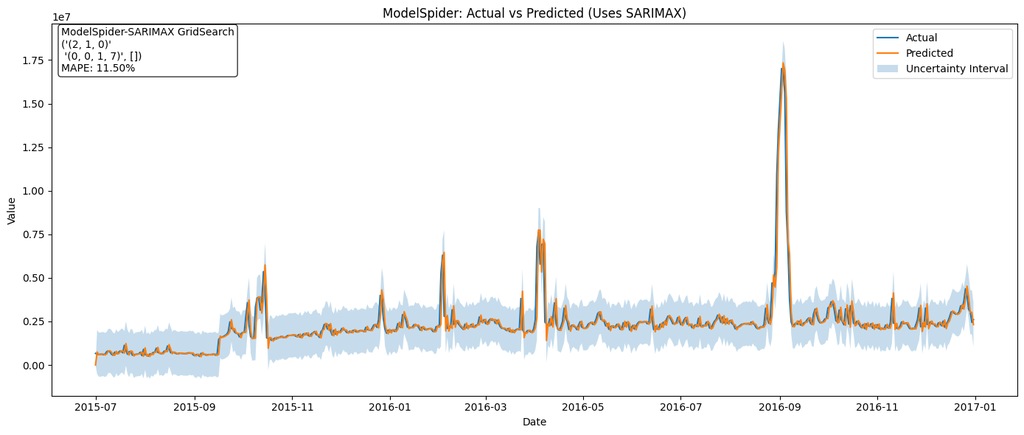

```
21:21:54 - cmdstanpy - INFO - Chain [1] start processing
21:21:54 - cmdstanpy - INFO - Chain [1] done processing
```

```
[ModelNonSpiderLangCommons]
--------------------------------------------------
  Fitted: Prophet
```

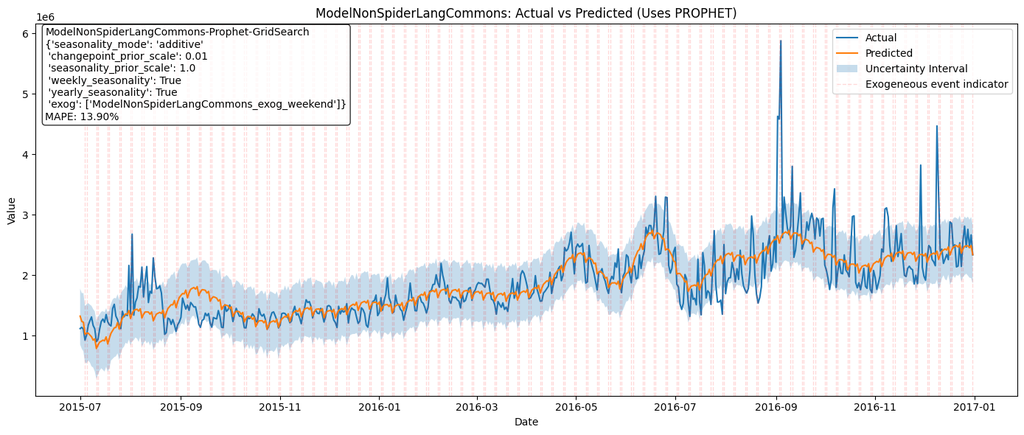

```
[ModelNonSpiderLangDe]
--------------------------------------------------
  Fitted: SARIMAX(1, 1, 1)x(1, 1, 0, 7)x['ModelNonSpiderLangDe_exog_weekend']
  AIC: 16449.2
```

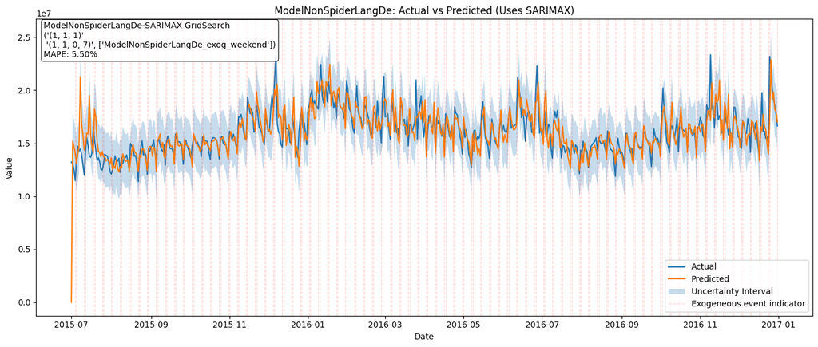

```
21:21:56 - cmdstanpy - INFO - Chain [1] start processing
21:21:56 - cmdstanpy - INFO - Chain [1] done processing
```

```
[ModelNonSpiderLangEn]
--------------------------------------------------
  Fitted: Prophet
```

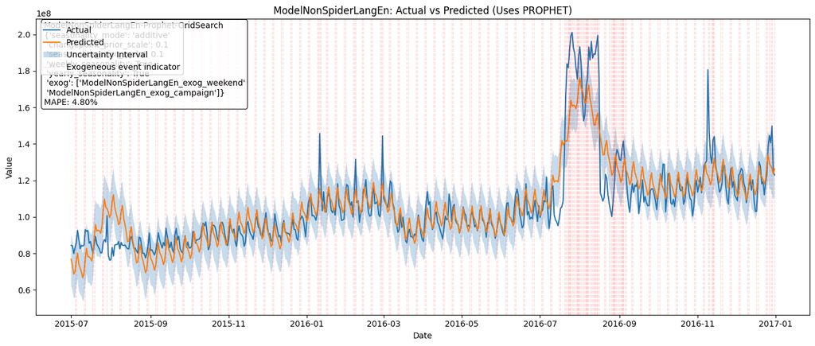

```
21:21:56 - cmdstanpy - INFO - Chain [1] start processing
21:21:56 - cmdstanpy - INFO - Chain [1] done processing
21:21:56 - cmdstanpy - ERROR - Chain [1] error: code '1' Operation not permitted
Optimization terminated abnormally. Falling back to Newton.
21:21:56 - cmdstanpy - INFO - Chain [1] start processing
```

```
[ModelNonSpiderLangEs]
--------------------------------------------------
```

```
21:21:57 - cmdstanpy - INFO - Chain [1] done processing
```

```
  Fitted: Prophet
```

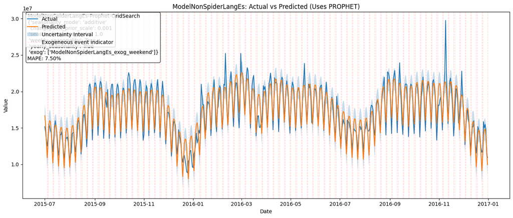

```
[ModelNonSpiderLangFr]
--------------------------------------------------
  Fitted: SARIMAX(4, 1, 1)x(1, 1, 0, 7)x['ModelNonSpiderLangFr_exog_weekend']
  AIC: 16192.5
```

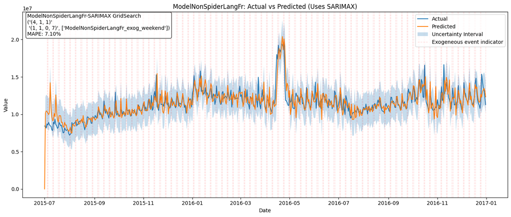

```
[ModelNonSpiderLangJa]
--------------------------------------------------
  Fitted: SARIMAX(1, 1, 0)x(1, 1, 1, 7)x['ModelNonSpiderLangJa_exog_weekend']
  AIC: 16812.7
```

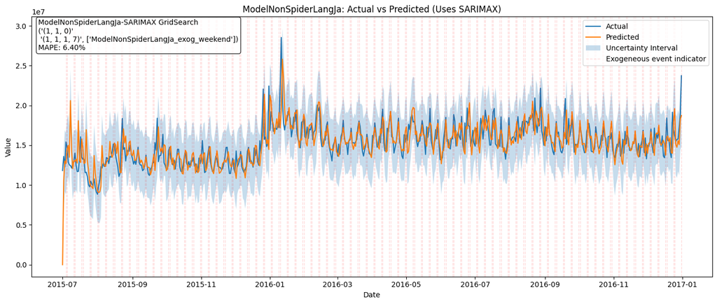

```
[ModelNonSpiderLangRu]
--------------------------------------------------
  Fitted: SARIMA(1, 0, 0)x(1, 1, 0, 7)x[]
  AIC: 17090.3
```

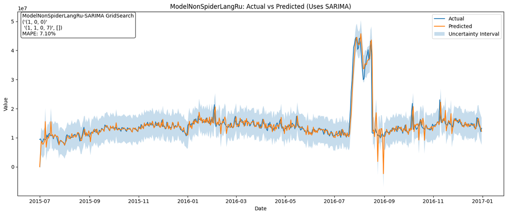

```
21:22:00 - cmdstanpy - INFO - Chain [1] start processing
21:22:00 - cmdstanpy - INFO - Chain [1] done processing
```

```
[ModelNonSpiderLangWww]
--------------------------------------------------
  Fitted: Prophet
```

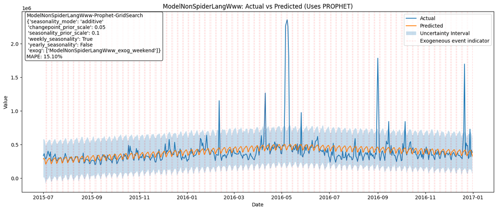

```
[ModelNonSpiderLangZh]
--------------------------------------------------
  Fitted: SARIMAX(2, 0, 1)x(0, 1, 1, 7)x['ModelNonSpiderLangZh_exog_weekend']
  AIC: 15438.6
```

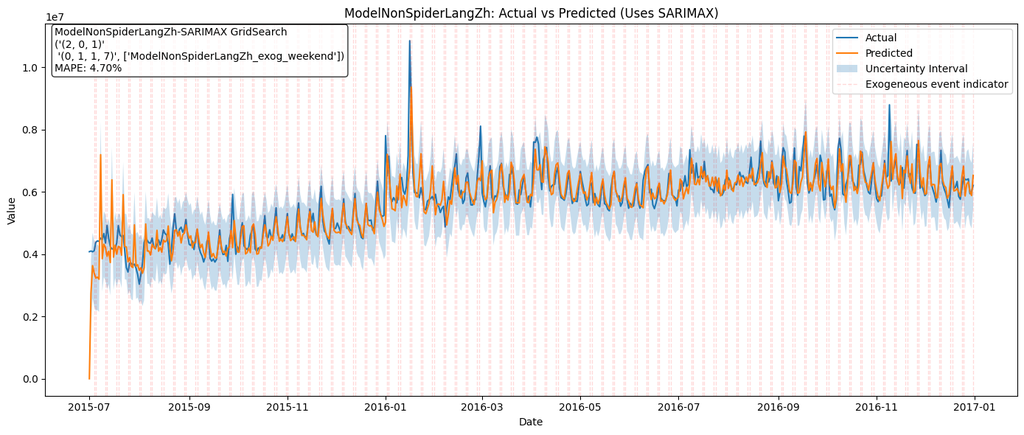

```python
# ============================================================
# RUN THE PIPELINE
# ============================================================

results = run_pipeline(modelDict, forecast_days=30)
fitted_models = results['fitted_models']
```